# How to regrid MOM6 using R and Python

Author

Jessica Bolin

Hi team. Allison Cluett wrote a python script for us: `_regrid.py`, that regrids MOM6 output from its native grid to a normal/rectilinear/WGS84 grid. I’m not good with python yet, so I have adapted this script for use with `{reticulate}`. This should make it easier to regrid MOM6 output for R users with little-to-no python knowledge. See walk-through below.

The hardest part of this script is simply getting python and your virtual environment (i.e., venv) set up. I have created a venv called `environment.yml` that contains the necessary python modules for this script. Once this is configured properly on your local machine, it should be smooth sailing.

Note that I use macOS.

# Install stuff and configure session

1. Install Anaconda. This installs `conda` which we use for configuring virtual enviornments: https://www.star.nesdis.noaa.gov/atmospheric-composition-training/software_anaconda_install.php
2. (Not compulsory): Open `data/regrid_example_jb/environment.yml` in RStudio. It will look like the below. This is a virtual environment (i.e., venv) I created with pre-installed modules/libraries and python version we need to regrid MOM6. The only important thing you need to be aware of is the name of the venv: `xesmf_env_2`.

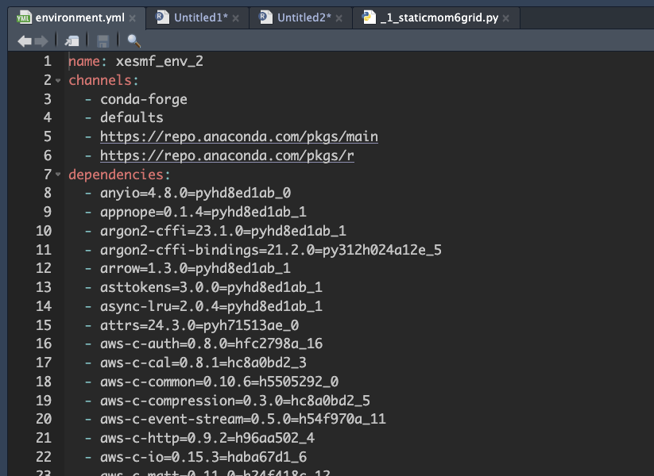

3. Open terminal. Run `conda env create -f /Users/admin/Documents/GitHub/CCSEcolForecasts/data/regrid_example_jb/environment.yml`. This gets the venv above, and uses `conda` to create the environment on your local machine. You can check it worked by running `conda env list`, and it should display the path to the venv. I have 4 venvs, but you should only have 2 if using `conda` for the first time (i.e., `base` and `xesmf_env_2`).

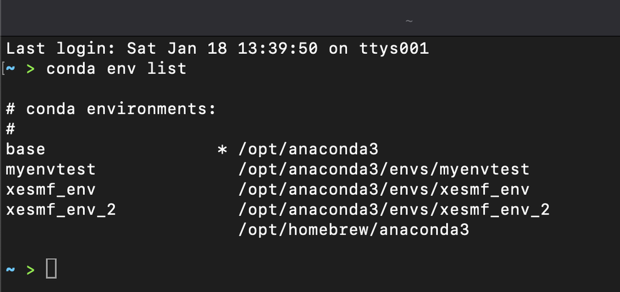

4. Open RStudio. Change the default python interpreter from 3.13/whatever is displayed to 3.12 that comes within the Anaconda distribution.

`Tools -> Global Options -> Python -> Select -> Conda Environments -> 3.12`

[figure not shown]

## R dependencies

```r
library(reticulate) # for using python in R
library(terra) #raster data
library(maps) # country outline

pth <- "/Users/admin/Documents/GitHub/CCSEcolForecasts/data/regrid_example_jb/"

#packageVersion("reticulate") #‘1.40.0’
#packageVersion("terra") #‘1.7.78’
#packageVersion("maps") #‘3.4.2’
```

## Set up python venv in RStudio

This should reflect the path for `xesmf_env_2` after running `conda env list` in terminal. It might throw a warning about superseding the venv - ignore and move on.

```r
use_python("/opt/anaconda3/envs/xesmf_env_2/bin/python")
```

## Load in python modules from venv

Like loading R libraries (same same but different).

```r
sys <- import("sys")            # for checking python version/env
xarray <- import("xarray")      # for opening netcdfs
matplotlib <- import("matplotlib")  # for visualization
plt <- matplotlib$pyplot        # for visualization using matplotlib
xesmf <- import("xesmf")        # for regridding
```

## Check venv is working as it should

Make sure the python version is NOT 3.13! The `xesmf` module is not compatible with v3.13. I use v3.12.8.

```r
sys$version # 3.12.8 (make sure it's not 3.13!)
```

```
[1] "3.12.8 | packaged by conda-forge | (main, Dec  5 2024, 14:23:40) [Clang 18.1.8 ]"
```

```r
sys$executable # path to venv
```

```
[1] "/opt/anaconda3/envs/xesmf_env_2/bin/python"
```

OK. Looks like python and our venv is configured correctly and we can move on to regridding.

# Open and visualise stuff

## Static MOM6 grid

Open the MOM6 empty grid. It’s better to visualise the grid using Panoply as opposed to RStudio (select the `areacello` variable).

Note that Jessie created `ds_static.nc` using Allison’s code in `_staticmom6grid.py` on `ocean_daily.static.nc`. You do not need to run this code; you’re good to just read in `ds_static.nc`.

```r
NEP_static_file <- paste0(pth, "ds_static.nc")
ds_static <- xarray$open_dataset(NEP_static_file)
ds_static
```

```
<xarray.Dataset> Size: 30MB
Dimensions:       (xh: 342, xq: 343, yh: 816, yq: 817)
Coordinates:
  * xh            (xh) float64 3kB 229.1 229.2 229.3 229.3 ... 254.8 254.9 255.0
  * xq            (xq) float64 3kB 229.1 229.2 229.3 229.3 ... 254.8 254.9 255.0
  * yh            (yh) float64 7kB 13.86 13.93 14.0 14.07 ... 59.51 59.52 59.52
  * yq            (yq) float64 7kB 13.83 13.9 13.96 14.03 ... 59.51 59.52 59.53
Data variables: (12/27)
    Coriolis      (yq, xq) float32 1MB ...
    areacello     (yh, xh) float32 1MB ...
    areacello_bu  (yq, xq) float32 1MB ...
    areacello_cu  (yh, xq) float32 1MB ...
    areacello_cv  (yq, xh) float32 1MB ...
    deptho        (yh, xh) float32 1MB ...
    ...            ...
    wet           (yh, xh) float32 1MB ...
    wet_c         (yq, xq) float32 1MB ...
    wet_u         (yh, xq) float32 1MB ...
    wet_v         (yq, xh) float32 1MB ...
    lon           (yh, xh) float32 1MB ...
    lat           (yh, xh) float32 1MB ...
Attributes:
    external_variables:  areacello areacello
```

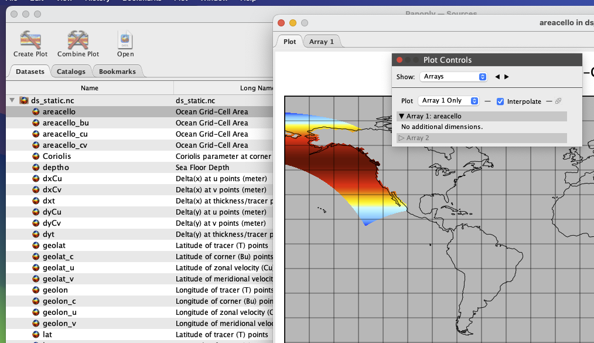

## ROMS (or other) file

This file is important. This netCDF needs to have the extent, CRS and projection we want to regrid our MOM6 to. In this example, I’m using 3km CC ROMS from Mer Pozo-Buil from my abalone work (specifically this is bottom temp for January 1st 1990 from GFDL for all coastal cells to 150m depth off California). As confirmed by reading in the file with `terra::rast()`, you can see the CRS is WGS84, the extent is off California, and has 3 km resolution.

```r
roms_file <- paste0(pth, 'gfdltv_1990_temp.nc')
roms <- xarray$open_dataset(roms_file) # read in with python
roms
```

```
<xarray.Dataset> Size: 332kB
Dimensions:            (longitude: 286, latitude: 286, time: 1)
Coordinates:
  * longitude          (longitude) float64 2kB -126.0 -126.0 ... -116.5 -116.5
  * latitude           (latitude) float64 2kB 41.99 41.95 41.92 ... 32.55 32.52
  * time               (time) datetime64[ns] 8B 1990-01-01
Data variables:
    gfdltv_1990_temp1  (time, latitude, longitude) float32 327kB ...
    crs                int32 4B ...
Attributes:
    Conventions:  CF-1.4
    created_by:   R packages ncdf4 and terra (version 1.7-78)
    date:         2025-01-18 17:49:52
```

```r
# Visualise in R, just because...
rr <- terra::rast(roms_file)[[1]]
rr
```

```
class       : SpatRaster
dimensions  : 286, 286, 1  (nrow, ncol, nlyr)
resolution  : 0.03321678, 0.03323263  (x, y)
extent      : -126, -116.5, 32.49849, 42.00302  (xmin, xmax, ymin, ymax)
coord. ref. : lon/lat WGS 84 (EPSG:4326)
source      : gfdltv_1990_temp.nc
varname     : gfdltv_1990_temp1
name        : gfdltv_1990_temp1
time (days) : 1990-01-01
```

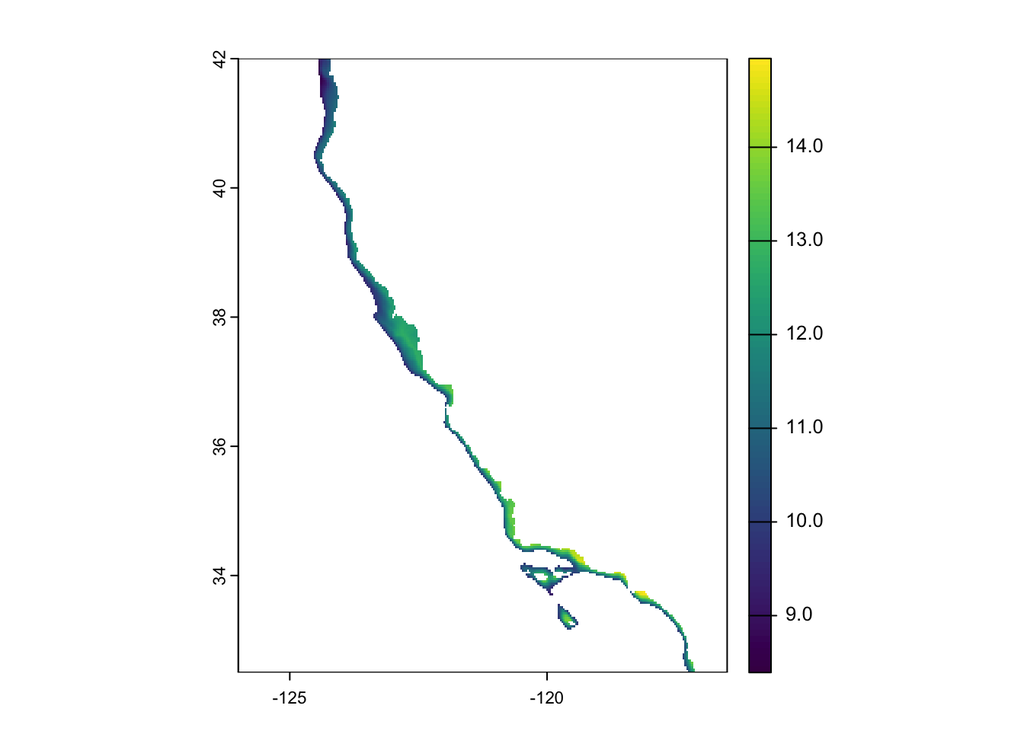

```r
plot(rr)
```

### Assign coordinates to ROMS file

I am creating two coordinates, `lon` and `lat`, with the values of the `longitude` and `latitude` in ROMS. Longitude and latitude must reflect the naming convention of the ROMS netcdf. This creates two new objects for `lon` and `lat` in the `Coordinates` field.

```r
roms <- roms$assign_coords(list(lon = roms$longitude, lat = roms$latitude))
roms
```

```
<xarray.Dataset> Size: 336kB
Dimensions:            (longitude: 286, latitude: 286, time: 1)
Coordinates:
  * longitude          (longitude) float64 2kB -126.0 -126.0 ... -116.5 -116.5
  * latitude           (latitude) float64 2kB 41.99 41.95 41.92 ... 32.55 32.52
  * time               (time) datetime64[ns] 8B 1990-01-01
    lon                (longitude) float64 2kB -126.0 -126.0 ... -116.5 -116.5
    lat                (latitude) float64 2kB 41.99 41.95 41.92 ... 32.55 32.52
Data variables:
    gfdltv_1990_temp1  (time, latitude, longitude) float32 327kB ...
    crs                int32 4B ...
Attributes:
    Conventions:  CF-1.4
    created_by:   R packages ncdf4 and terra (version 1.7-78)
    date:         2025-01-18 17:49:52
```

## MOM6 files

Read in the MOM6 files we want to regrid. Again, use panoply to visualise a file of interest. See how the projection is way off.

```r
# MOM6 file
fileys <- list.files(pth)[grep("ocean_monthly", list.files(pth))]  # MOMS files
fileys <- fileys[!grepl("_RG.nc", fileys)] #exclude any regridded files that already exist in directory
fileys
```

```
[1] "ocean_monthly.199801-200212.chlos.nc"
[2] "ocean_monthly.201301-201712.tos.nc"
```

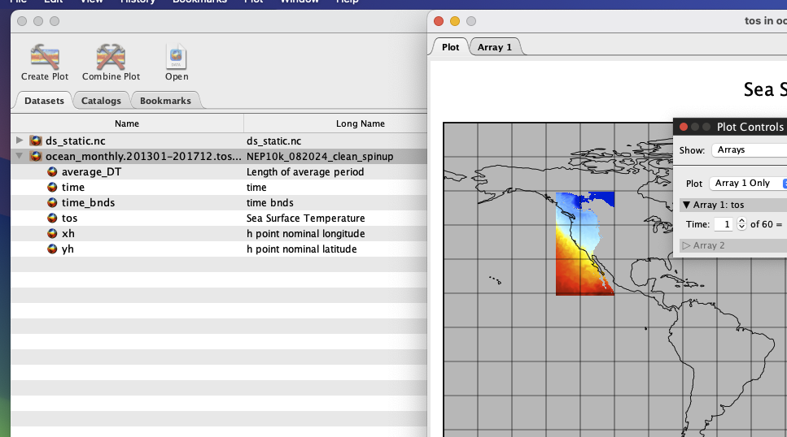

# Function to regrid

Here is the function to regrid the files. Below, we’ll go through it line by line. Note that the function includes a conditional to skip files if they’ve already been regridded and exist in the directory.

```r
regrid_MOM6 <- function(mom6_file) {

  filename <- gsub(pth, "", mom6_file)
  filename <- gsub(".nc", "_RG.nc", filename)

  if (!file.exists(paste0(pth, filename))) {

  ds <- xarray$open_dataset(mom6_file)
  mom_to_roms <- xesmf$Regridder(ds_static, roms, method = 'bilinear', unmapped_to_nan = TRUE)
  mom6_regrid <- (mom_to_roms(ds))$to_netcdf(path = paste0(pth, filename))
  } else {
    print(paste0("skipping iteration ", fileys[i]))

    } # if then
} # function
```

### Step 1. Set `mom6_file`

Here we’re using the first MOM6 file in directory as an example.

```r
mom6_file = paste0(pth, fileys[1])
mom6_file
```

```
[1] "/Users/admin/Documents/GitHub/CCSEcolForecasts/data/regrid_example_jb/ocean_monthly.199801-200212.chlos.nc"
```

### Step 2. Define output filename with `_RG.nc` suffix

```r
 filename <- gsub(pth, "", mom6_file)
 filename <- gsub(".nc", "_RG.nc", filename)
 filename
```

```
[1] "ocean_monthly.199801-200212.chlos_RG.nc"
```

### Step 3. Open the file

```r
ds <- xarray$open_dataset(mom6_file)
ds
```

```
<xarray.Dataset> Size: 67MB
Dimensions:     (time: 60, yh: 816, xh: 342, nv: 2)
Coordinates:
  * nv          (nv) float64 16B 1.0 2.0
  * time        (time) datetime64[ns] 480B 1998-01-16T12:00:00 ... 2002-12-16...
  * xh          (xh) float64 3kB 229.1 229.2 229.3 229.3 ... 254.8 254.9 255.0
  * yh          (yh) float64 7kB 13.86 13.93 14.0 14.07 ... 59.51 59.52 59.52
Data variables:
    average_DT  (time) timedelta64[ns] 480B ...
    average_T1  (time) datetime64[ns] 480B ...
    average_T2  (time) datetime64[ns] 480B ...
    chlos       (time, yh, xh) float32 67MB ...
    time_bnds   (time, nv) datetime64[ns] 960B ...
Attributes:
    NumFilesInSet:       1
    title:               NEP10k_082024_clean_spinup
    associated_files:    areacello: 19980101.ocean_static.nc
    grid_type:           regular
    grid_tile:           N/A
    external_variables:  areacello
```

### Step 4. Define python function for regridding

Here we are using bilinear interpolation for regridding the MOM6 grid to the 3 km ROMS grid.

```r
mom_to_roms <- xesmf$Regridder(ds_static, # MOM6 empty grid
                               roms, # ROMS grid
                               method = 'bilinear',
                               unmapped_to_nan = TRUE)
```

### Step 5. Run python regrid function and save output to directory

```r
mom6_regrid <- (mom_to_roms(ds))$to_netcdf(path = paste0(pth, filename))
list.files(pth, pattern = "_RG.nc")
```

```
[1] "ocean_monthly.199801-200212.chlos_RG.nc"
```

### Step 6. Check using `terra`

```r
rr <- rast(paste0(pth, list.files(pth, pattern = "_RG.nc")))
rr #Has dimensions and extent etc. I want!
```

```
class       : SpatRaster
dimensions  : 286, 286, 60  (nrow, ncol, nlyr)
resolution  : 0.03321678, 0.03323263  (x, y)
extent      : -126, -116.5, 32.49849, 42.00302  (xmin, xmax, ymin, ymax)
coord. ref. : +proj=longlat +datum=WGS84 +no_defs
source      : ocean_monthly.199801-200212.chlos_RG.nc:chlos
varname     : chlos
names       : chlos_1, chlos_2, chlos_3, chlos_4, chlos_5, chlos_6, ...
time (days) : 1998-01-16 to 2002-12-16
```

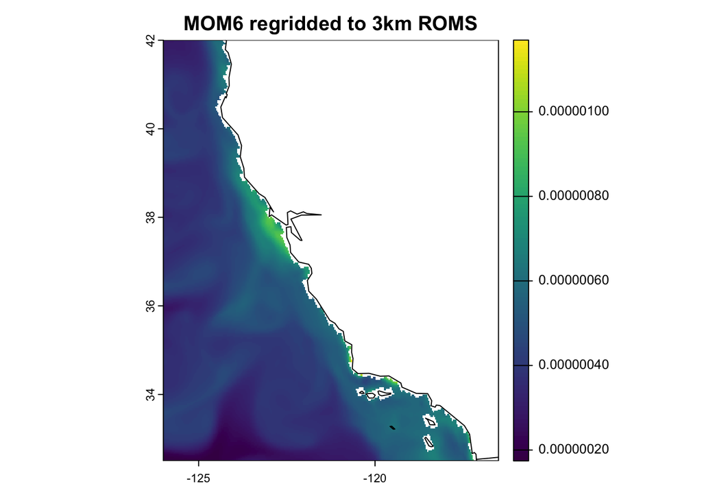

```r
plot(rr[[1]], main = "MOM6 regridded to 3km ROMS"); map("world", add= T) # *chef's kiss*
```